# Trabajo 1 Multivariado

Juan David Garcia Zapata

2023-09-01

# verificacion de Nas

```
## .
## FALSE  TRUE
##  1791     9
```

```
##      Sexo                 P1               P7            P16
##  Length:200         Min.   : 43.40   Min.   :43.6   Min.   : 60.30
##  Class :character   1st Qu.: 56.80   1st Qu.:52.7   1st Qu.: 74.03
##  Mode  :character   Median : 66.20   Median :55.4   Median : 80.95
##                     Mean   : 66.14   Mean   :55.5   Mean   : 81.14
##                     3rd Qu.: 73.90   3rd Qu.:58.8   3rd Qu.: 87.53
##                     Max.   :101.20   Max.   :67.8   Max.   :105.10
##                     NA's   :1        NA's   :1      NA's   :2
##       P22             P27             P29             P38
##  Min.   :28.40   Min.   :21.00   Min.   :15.20   Min.   :143.6
##  1st Qu.:33.88   1st Qu.:23.40   1st Qu.:16.90   1st Qu.:157.4
##  Median :35.60   Median :24.20   Median :17.65   Median :165.1
##  Mean   :35.71   Mean   :24.32   Mean   :17.72   Mean   :164.3
##  3rd Qu.:37.52   3rd Qu.:25.30   3rd Qu.:18.50   3rd Qu.:170.4
##  Max.   :44.60   Max.   :27.90   Max.   :21.00   Max.   :184.1
##                  NA's   :2       NA's   :2       NA's   :1
##    CAT_IMC
##  Length:200
##  Class :character
##  Mode  :character
##
##
##
##
```

```
## [1] "Sexo"    "P1"      "P7"      "P16"     "P22"     "P27"     "P29"
## [8] "P38"     "CAT_IMC"
```

# cambio de nombre a variables

```
##   Sexo        Masa(kg)       Permuslo(cm)   Perabdo(cm)     Anchcaderas(cm)
##  Hom:125   Min.   : 43.40   Min.   :43.6   Min.   : 60.30   Min.   :28.40
##  Muj: 75   1st Qu.: 56.80   1st Qu.:52.7   1st Qu.: 74.03   1st Qu.:33.88
##            Median : 66.20   Median :55.4   Median : 80.95   Median :35.60
##            Mean   : 66.14   Mean   :55.5   Mean   : 81.14   Mean   :35.71
##            3rd Qu.: 73.90   3rd Qu.:58.8   3rd Qu.: 87.53   3rd Qu.:37.52
##            Max.   :101.20   Max.   :67.8   Max.   :105.10   Max.   :44.60
##            NA's   :1        NA's   :1      NA's   :2
##   Longpies(cm)    Longman(cm)     Estatura(cm)      Cat_imc
##  Min.   :21.00   Min.   :15.20   Min.   :143.6   DELGADO: 15
##  1st Qu.:23.40   1st Qu.:16.90   1st Qu.:157.4   NORMAL :155
##  Median :24.20   Median :17.65   Median :165.1   OBESO  : 30
##  Mean   :24.32   Mean   :17.72   Mean   :164.3
##  3rd Qu.:25.30   3rd Qu.:18.50   3rd Qu.:170.4
##  Max.   :27.90   Max.   :21.00   Max.   :184.1
##  NA's   :2       NA's   :2       NA's   :1
```

# 1 punto

## identenficación de NaN

```r
knitr::kable(table(is.na(datosf[,1])), format = "markdown", caption = "Conteo NAs  Sexo")
```

Conteo NAs Sexo

| Var1 | Freq |
| --- | --- |
| FALSE | 200 |

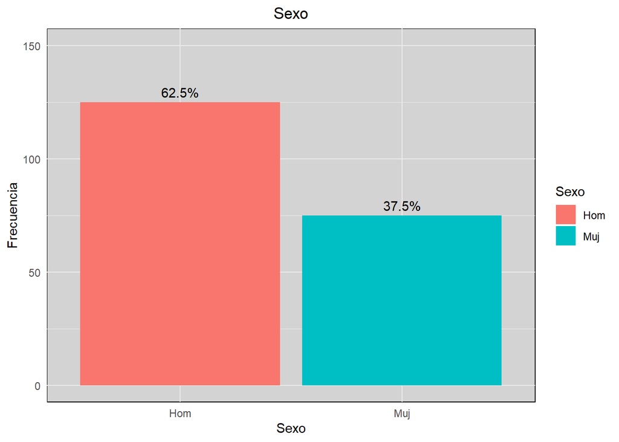

```r
porcentaje <- prop.table(table(datosf$Sexo)) * 100

# Crear el gráfico de barras con etiquetas de porcentaje y escala de y aumentada
ggplot(datosf, aes(x = Sexo, fill = Sexo)) +
  geom_bar() +
  geom_text(stat = "count", aes(label = scales::percent(..count.. / sum(..count..), accuracy = 0.1)), vjust = -0.5) +
  labs(
    title = "Sexo",
    x = "Sexo",
    y = "Frecuencia"
  ) +
  theme_minimal() +
  scale_y_continuous(limits = c(0, 150)) +  # Cambia el tema del gráfico
  theme(panel.background = element_rect(fill = "lightgray"),  # Elimina los nombres en el eje x
        plot.title = element_text(hjust = 0.5),  # Centra el título del gráfico
        axis.title.x = element_text(hjust = 0.5))
```

# Masa

```r
knitr::kable(table(is.na(datosf[,2])), format = "markdown", caption = "Conteo NAs  Masa")
```

Conteo NAs Masa

| Var1 | Freq |
| --- | --- |
| FALSE | 199 |
| TRUE | 1 |

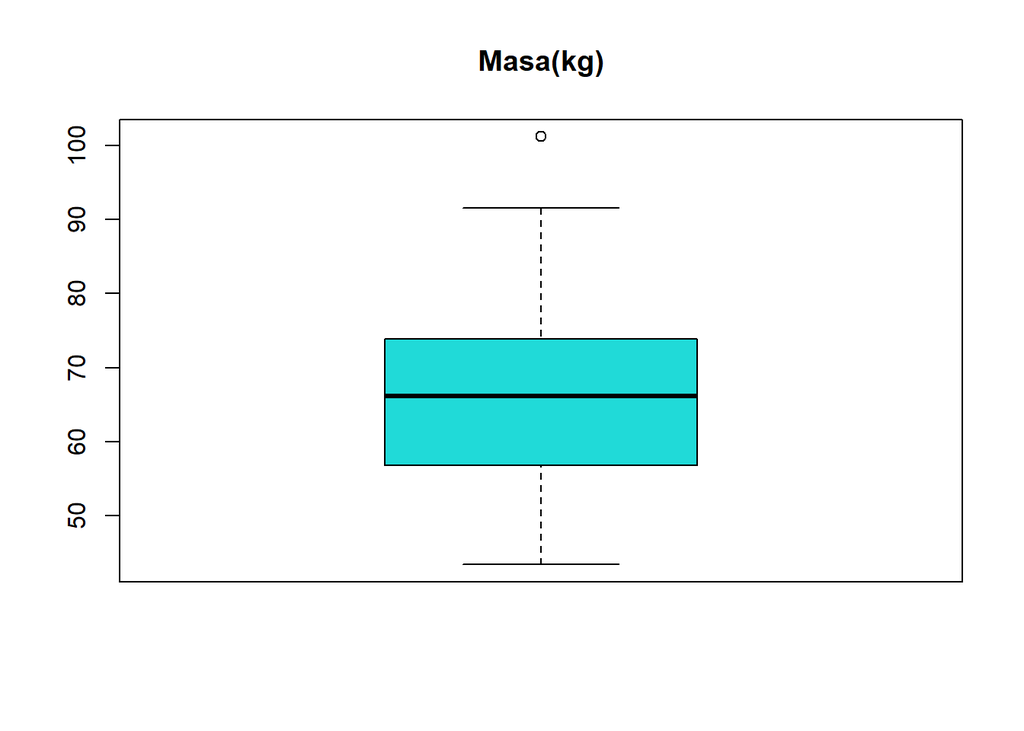

```r
v2 <- boxplot(datosf$`Masa(kg)`, col = colores[1], horizontal = F, main = "Masa(kg)")
```

## Cuantos datos atipicos hay

```r
aa <- data.frame(v2$out)
colnames(aa)= "Atipicos"
aa
```

```
##   Atipicos
## 1    101.2
```

## identificacion del dato atipico

```r
valor_buscado <- 101.2

# Usando la función which() junto con la indexación de filas
fila_con_valor <- datosf[which(datosf$`Masa(kg)` == valor_buscado), ]

# fila_con_valor contendrá la fila que contiene el valor buscado
print(fila_con_valor)
```

```
##    Sexo Masa(kg) Permuslo(cm) Perabdo(cm) Anchcaderas(cm) Longpies(cm)
## 11  Hom    101.2         67.8       104.3              42           NA
##    Longman(cm) Estatura(cm) Cat_imc
## 11        20.2        179.5   OBESO
```

# Perímetro muslo mayor(cm)

## identificación de NaN

```r
knitr::kable(table(is.na(datosf[,3])), format = "markdown", caption = "Conteo NAs  Perímetro muslo mayor(cm)")
```

Conteo NAs Perímetro muslo mayor(cm)

| Var1 | Freq |
| --- | --- |
| FALSE | 199 |
| TRUE | 1 |

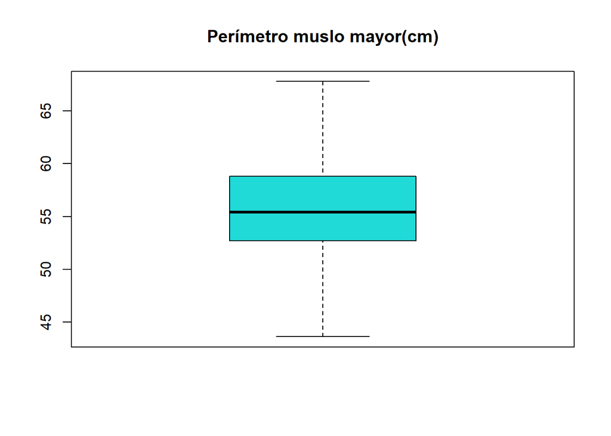

```r
v3 <- boxplot(datosf[,3], col = colores[1], horizontal = F, main = "Perímetro muslo mayor(cm)")
```

# Perímetro abdominal cintura(cm)

## identificación de NaN

```r
knitr::kable(table(is.na(datosf[,4])), format = "markdown", caption = "Conteo NAs  Perímetro abdominal cintura(cm)")
```

Conteo NAs Perímetro abdominal cintura(cm)

| Var1 | Freq |
| --- | --- |
| FALSE | 198 |
| TRUE | 2 |

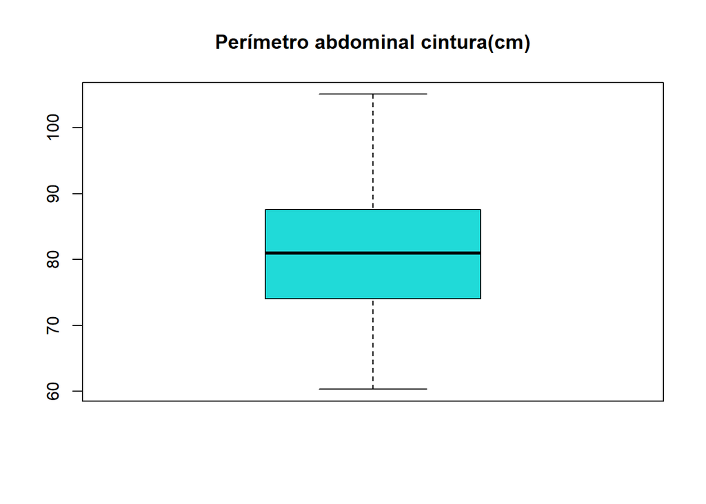

```r
v4 <- boxplot(datosf[,4], col = colores[1], horizontal = F, main = "Perímetro abdominal cintura(cm)")
```

En el gráficos, podemos observar que ocurre lo mismo que con la variable ‘Perímetro muslo mayor(cm)’: no se encuentran datos atípicos. Sin embargo, al examinar la tabla, podemos notar que existen 2 valores faltantes (NaN) que requieren imputación.

# Anchura de las caderas

## identificación de NaN

```r
knitr::kable(table(is.na(datosf[,5])), format = "markdown", caption = "Conteo NAs  Anchura de las caderas")
```

Conteo NAs Anchura de las caderas

| Var1 | Freq |
| --- | --- |
| FALSE | 200 |

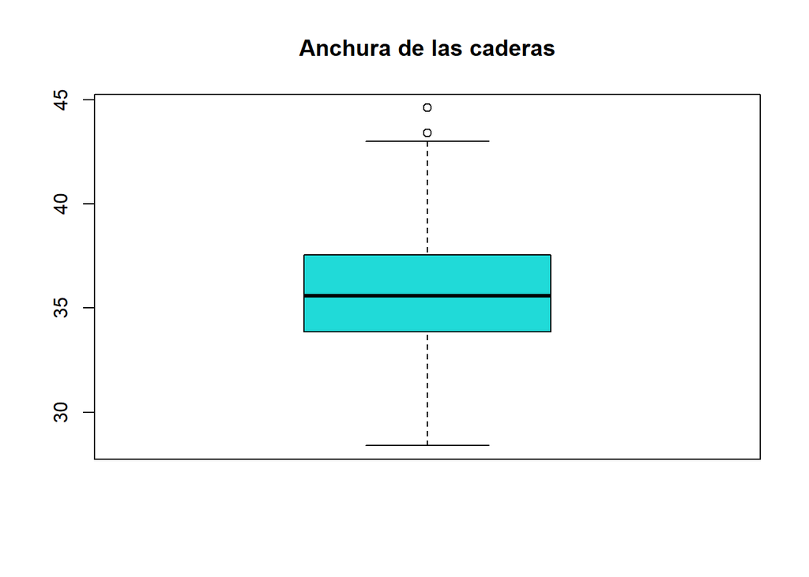

```r
v5 <- boxplot(datosf[,5], col = colores[1], horizontal = F, main = "Anchura de las caderas")
```

```r
aa1 <- data.frame(v5$out)
colnames(aa1)= "Atipicos"
aa1
```

```
##   Atipicos
## 1     43.4
## 2     44.6
```

## identificacion del dato atipico

```r
# Usando la función which() junto con la indexación de filas
fila_con_valor1 <- datosf[which(datosf$`Anchcaderas(cm)` == c(43.4,44.6)), ]

# fila_con_valor contendrá la fila que contiene el valor buscado
print(fila_con_valor1)
```

```
##   Sexo Masa(kg) Permuslo(cm) Perabdo(cm) Anchcaderas(cm) Longpies(cm)
## 1  Muj     89.7         67.6        96.6            43.4         24.2
## 8  Muj     86.1           NA        93.4            44.6         24.2
##   Longman(cm) Estatura(cm) Cat_imc
## 1        18.7        167.3   OBESO
## 8        17.8        169.6   OBESO
```

En el gráfico se pueden observar datos que podrían considerarse atípicos, por lo que es necesario verificar si realmente cumplen con esta clasificación. En cuanto a la presencia de valores NaN, no encontramos ninguno en la variable. Además, respecto a los datos atípicos, se identificaron dos, pero es importante destacar que después de un análisis más detenido, concluimos que estos datos no pueden ser considerados atípicos. Todas las variables en estos registros son muy similares y concuerdan con las características esperadas en la realidad.

# Anchura de las caderas(cm)

Primero veremos si hay valores faltantes en esta variable

Conteo NAs ancho cadera

| Var1 | Freq |
| --- | --- |
| FALSE | 200 |

Como se puede ver en la tabla, no existen valores faltantes, por lo tanto no nos tendremos que preocupar por esto posteriormente.

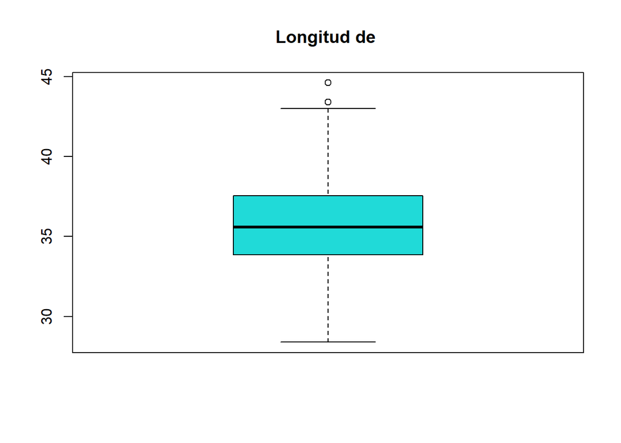

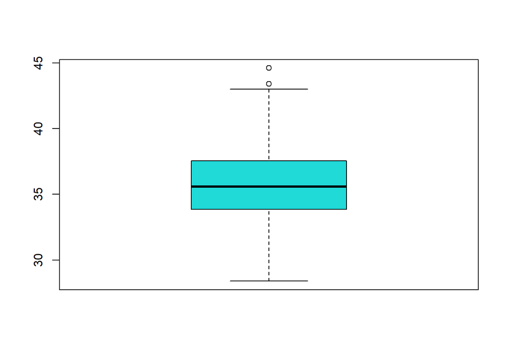

[output not shown]

## Longpies (cm)

Primero veremos si existen valores faltantes (NAs):

| Var1 | Freq |
| --- | --- |
| FALSE | 198 |
| TRUE | 2 |

Como podemos en la tabla, existen 2 valores que faltan (NAs) para esta metrica, por lo tanto posteriormente proceremos a imputarlos.

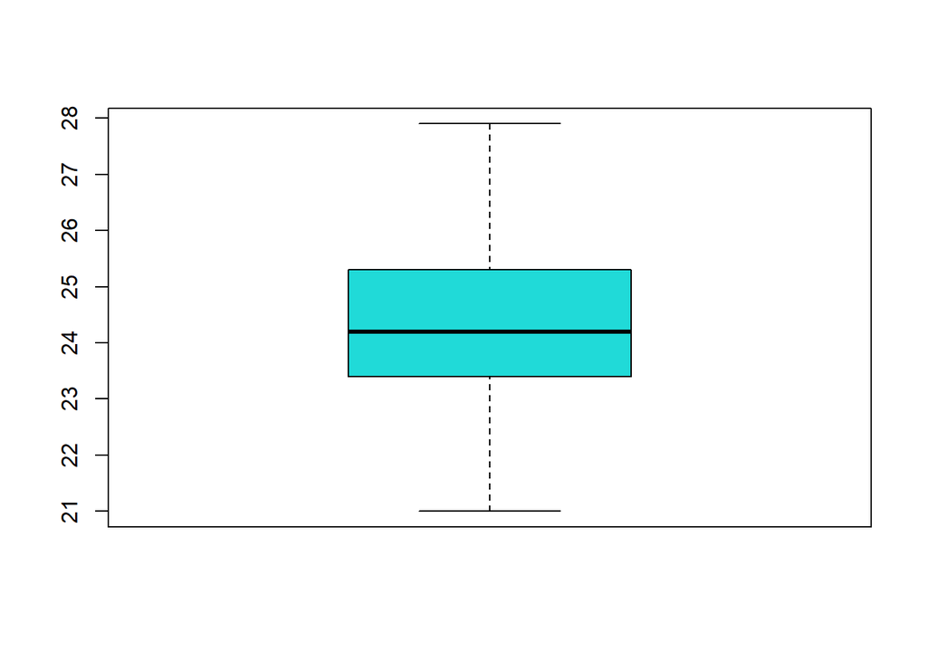

Como podemos ver en el boxplot no hay valores que esten a mas de 1.5 veces del rango intercuartil (valores atipicos).

## Longmano (cm)

Para iniciar el analisis veremos si existen valores faltantes para esta metrica

| Var1 | Freq |
| --- | --- |
| FALSE | 198 |
| TRUE | 2 |

En este igual que en los anteriores podemos ver igual que vimos en metricas anteriores hay 2 valores faltantes, posteriormente tendremos que imputar estos datos.

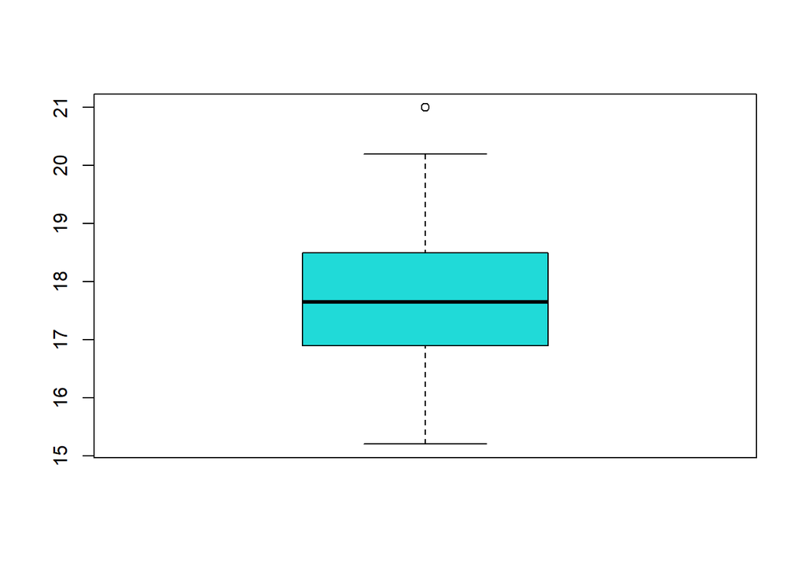

En este boxplot existen valores atipicos (valores a mas de 1.5 veces del rango interquartil).

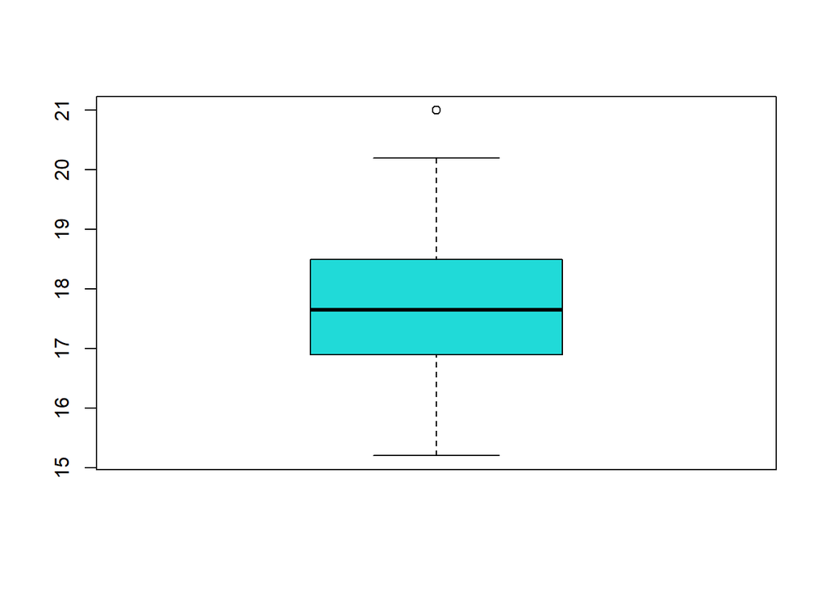

| Valores.atipicos |
| --- |
| 21 |

## Estatura (cm)

Primero veremos si existen valores faltantes para esta metrica:

| Var1 | Freq |
| --- | --- |
| FALSE | 199 |
| TRUE | 1 |

Como podemos ver, hay un NAs en este caso, por lo tanto mas adelante procederemos a imputar el dato.

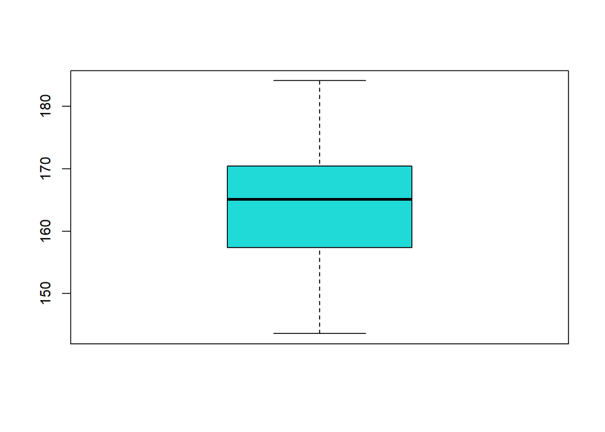

Para este caso no hay valores atipicos.

## IMC

Primero veremos la existencia de valores faltantes para esta metrica.

| Var1 | Freq |
| --- | --- |
| FALSE | 200 |

En este caso no hay valores faltantes, por lo tanto no nos tendremos que preocupar por imputacion de datos

# Imputacion

## Longpies

De forma empirica sabemos que normalmente la longitud de los pies de los hombres es mayor, ya que en su mayoria tienen un tallaje mayor que el de las mujeres. Este supuesto nos da una idea de que pueda haber una diferencia entre hombres y mujeres con respecto a esta caracteristica, pero hay que visualizar los datos para ver realmente en nuestro caso que pasa.

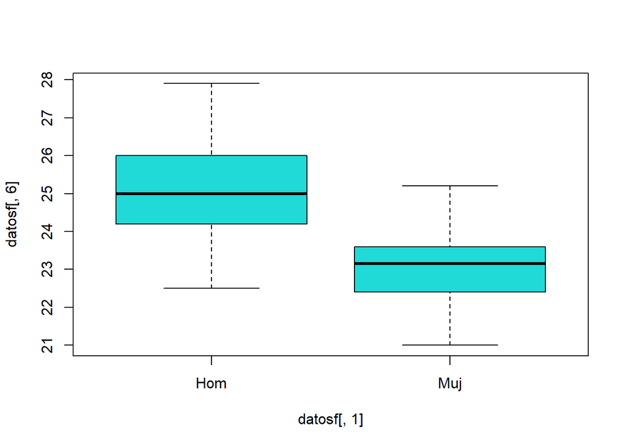

Como podemos en el boxplot la cajas no se traslapan, por lo tanto hay una diferencia significativa entre ambos grupos, ademas de esto, cabe recalcar que para el caso de los hombres se ve bastante simetrica la distribucion de los datos por lo tanto la mediana y la media deberian de darnos valores muy parecidos (cercanos entre si) o iguales (en el caso en el que sea completamente simetrico) asi que no va a haber una diferencia significativa entre imputar con uno o otro, pero para el caso de las mujeres podemos ver que la distribucion de los datos no es simetrica, por lo tanto hay que mirar este caso con mas detenimiento y asi determinar que metodo usar, asi que imputaremos el dato a traves de la media, dependiendo del sexo a el que pertenezca la persona.

Estos son los registros que tienen ausencia de esta metrica (NAs).

|  | Sexo | Masa(kg) | Permuslo(cm) | Perabdo(cm) | Anchcaderas(cm) | Longpies(cm) | Longman(cm) | Estatura(cm) | Cat_imc |
| --- | --- | --- | --- | --- | --- | --- | --- | --- | --- |
| 11 | Hom | 101.2 | 67.8 | 104.3 | 42.0 | NA | 20.2 | 179.5 | OBESO |
| 49 | Muj | 59.6 | 53.8 | 68.3 | 34.5 | NA | 18.1 | 161.8 | NORMAL |

### Usando R para imputar datos

**Paso 1:**

Para hacerlo de una forma mas simple, sacaremos una sub base de datos en la cual solo existiran 2 columnas las cuales son: Sexo y Longpies(cm).

```r
nb1 <- subset(datosf, select = c("Sexo","Longpies(cm)"))

knitr::kable(head(nb1), format = "markdown", caption = "Head Longpies(cm)")
```

Head Longpies(cm)

| Sexo | Longpies(cm) |
| --- | --- |
| Muj | 24.2 |
| Muj | 23.4 |
| Hom | 24.6 |
| Muj | 22.8 |
| Muj | 23.6 |
| Hom | 26.1 |

**Paso 2**

La imputacion para el hombre la haremos con R, en el caso de la mujer lo haremos con excel.

**Imputacion registro 11, sexo:Hombre**

Para probar la hipotesis que planteamos al principio, tambien haremos el calculo de la mediana.

```r
imput1 <- filter(nb1, Sexo == "Hom")

knitr::kable(data.frame( "Mean" = mean(imput1$`Longpies(cm)`, na.rm = TRUE ),
            "Median" = median(imput1$`Longpies(cm)`,
                              na.rm = TRUE )),
            format = "markdown", caption = "Media y Medina hombres")
```

Media y Medina hombres

| Mean | Median |
| --- | --- |
| 25.11048 | 25 |

Finalmente nos quedaremos con la media ya que no existen valores atipicos los cuales nos lleven a pensar acerca de usar la mediana.

**Paso 3: Imputacion**

Ahora solo queda que busquemos el registro en la base de datos y lo imputamos con el valor de la media ya calculado.

```r
datosf[11,6] <- mean(imput1$`Longpies(cm)`, na.rm = TRUE )
```

|  | Sexo | Masa(kg) | Permuslo(cm) | Perabdo(cm) | Anchcaderas(cm) | Longpies(cm) | Longman(cm) | Estatura(cm) | Cat_imc |
| --- | --- | --- | --- | --- | --- | --- | --- | --- | --- |
| 11 | Hom | 101.2 | 67.8 | 104.3 | 42 | 25.11048 | 20.2 | 179.5 | OBESO |

### Imputando datos con excel

Primero exportamos nuestra base de datos desde R con el siguiente codigo: **writexl::write_xlsx(datosf,“datos.xlsx”)**

Habrimos excel:

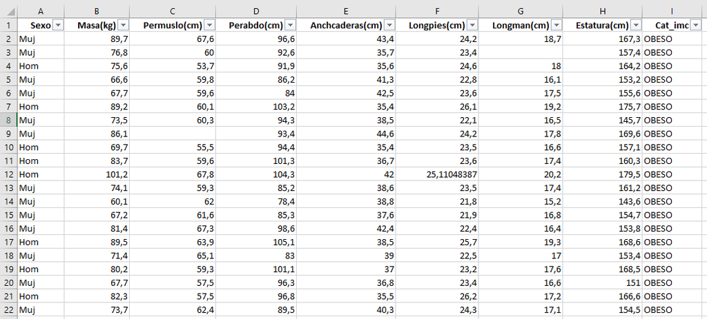

Ocultamos el resto de columnas que no nos son utiles para este caso y solo degamos la columna Sexo y Longpies(cm), despues de esto procedemos a usar la funcion **FILTER** (hay que tener en cuenta que en este caso el excel esta en ingles, por lo tanto para el caso en español o otros idiomas cambia la palabra) para crear una tabla en la cual filtraremos por el la columna Sexo por el valor **“Muj”**

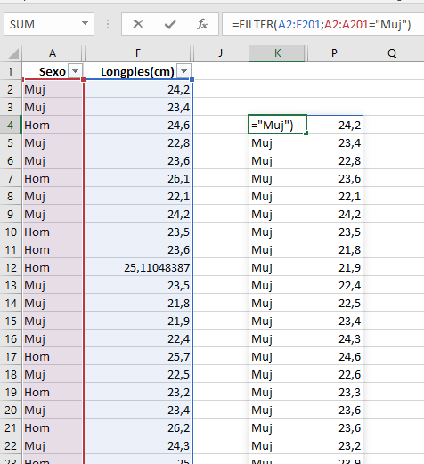

Luego calculamos el promedio con la funcion **AVERAGE**, lo haremos con esta ya que no hay valores atipicos los cuales puedan afectar la estimacion de la media

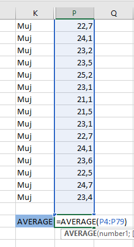

Despues de tener el valor filtramos en la columna sexo por los valores vacios

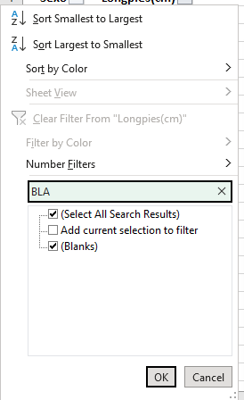

Y procedemos por ultimo a imputar el dato, es muy importante saber lo siguiente, que en el caso de excel nuestro dato faltante esta en la fila **50**, ya que la primera fila para nosotros son los nombres de las columnas, en cambio en R los registros empiezan desde el numero 1.

## Longmano

Por la experiencia y lo vemos dia a dia, sabemos que las manos de las mujeres son mas pequeñas que las de los hombres, y tambien es algo escaso cuando un hombre tiene la mano mas pequeña que la de la mujer, asi que el dia a dia nos indica que puede haber una diferencia significativa entre ambos sexos, ahora veremos los datos para corroborar nuestro hipotesis.

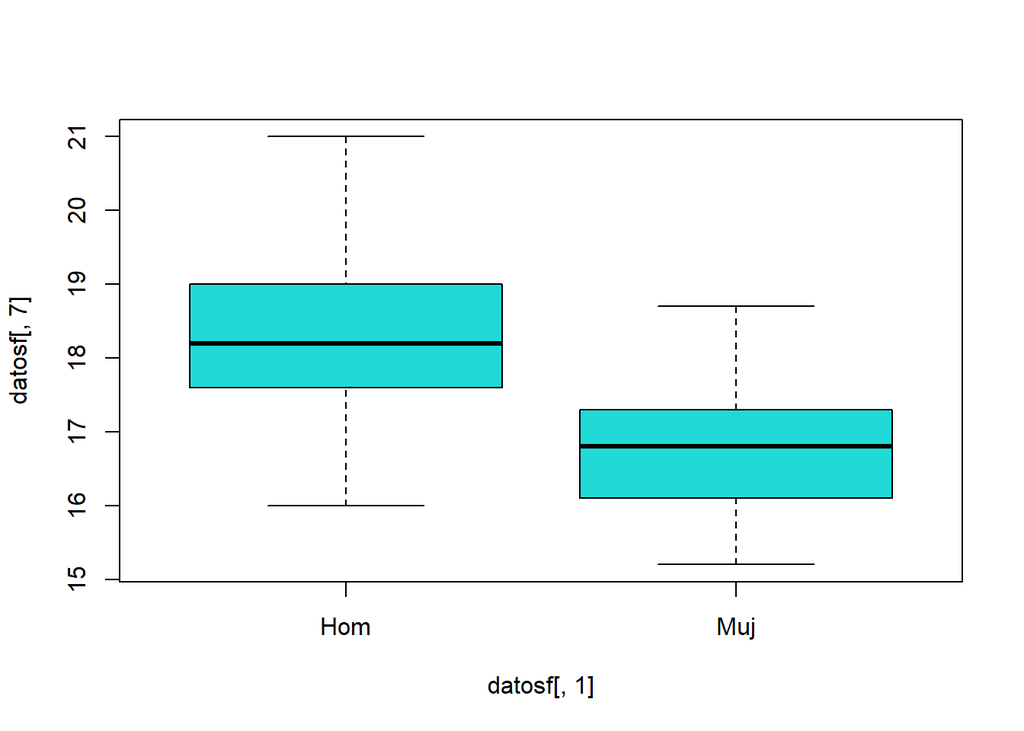

Como las cajas no se traslapan, confirmamos nuestra hipotesis empirica y por lo tanto hay una diferencia significativa entre hombres y mujeres en la medida de la longitud de la mano

**Registros con los valores faltantes**

Como en el caso anterior, un registro faltante corresponde a mujeres y el otro a hombres, asi que hay que sacar la media de cada grupo y hacer la imputacion al registro que corresponde a dicho grupo.

Imputacion Longman (cm)

|  | Sexo | Masa(kg) | Permuslo(cm) | Perabdo(cm) | Anchcaderas(cm) | Longpies(cm) | Longman(cm) | Estatura(cm) | Cat_imc |
| --- | --- | --- | --- | --- | --- | --- | --- | --- | --- |
| 2 | Muj | 76.8 | 60.0 | 92.6 | 35.7 | 23.4 | NA | 157.4 | OBESO |
| 192 | Hom | 55.4 | 48.5 | 72.2 | 29.6 | 23.4 | NA | 172.0 | DELGADO |

Imputacion Longman (cm)

|  | Sexo | Masa(kg) | Permuslo(cm) | Perabdo(cm) | Anchcaderas(cm) | Longpies(cm) | Longman(cm) | Estatura(cm) | Cat_imc |
| --- | --- | --- | --- | --- | --- | --- | --- | --- | --- |
| 192 | Hom | 55.4 | 48.5 | 72.2 | 29.6 | 23.4 | 18.29355 | 172 | DELGADO |

Imputacion Longman (cm)

|  | Sexo | Masa(kg) | Permuslo(cm) | Perabdo(cm) | Anchcaderas(cm) | Longpies(cm) | Longman(cm) | Estatura(cm) | Cat_imc |
| --- | --- | --- | --- | --- | --- | --- | --- | --- | --- |
| 2 | Muj | 76.8 | 60 | 92.6 | 35.7 | 23.4 | 16.75 | 157.4 | OBESO |

## Estatura

Dia a dia vemos como las mujeres son mas bajas en comparacion a los hombres, por ejemplo en la mayoria de los casos un hijo varon supera la estatura de su mama facilmente y la de sus compañeras de clase, trabajo, etc y para el caso de las mujeres es bastante atipico que alguna mida 190 cm o 185 cm, en cambio en un hombre, aunque no es comun, si es mas logico en ellos y ademas mas comun en comparacion a las mujeres. Veremos los datos para probar o desmentir esta hipotesis

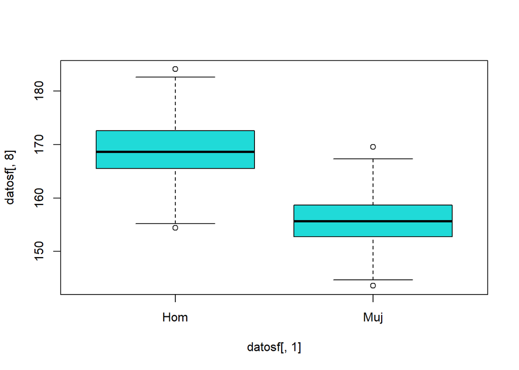

```r
boxplot(datosf[,8] ~ datosf[,1], col = colores[1])
```

Aqui como en los otros casos vemos una diferencia signicativa entre ambos grupos ya que las cajas no se traslapan y por lo tanto, para imputar el dato hay que hacer calculo grupo por grupo. Y hay que tener en cuenta otra cosa, que en ambos hay valores atipicos, y tampoco es algo como muy extremo.

Faltantes Estatura

|  | Sexo | Masa(kg) | Permuslo(cm) | Perabdo(cm) | Anchcaderas(cm) | Longpies(cm) | Longman(cm) | Estatura(cm) | Cat_imc |
| --- | --- | --- | --- | --- | --- | --- | --- | --- | --- |
| 199 | Muj | 53.4 | 53.4 | 67.7 | 35.9 | 24.7 | 17.1 | NA | DELGADO |

en nuestro caso el dato faltante corresponde a una mujer y como vimos en el diagrama de boxplot hay 2 valores atipicos, los cuales son: **169.6 y 143.6**, estos dos como estan en lados contrarios, entonces de alguna forma equilibran la carga en la media. Para probar esto haremos lo siguiente: calcularemos la media con y sin valores atipicos y veremos si hay una diferencia significativa.

**Sin valores atipicos**

```
## [1] 155.8569
```

**Con valores atipicos**

```
## [1] 155.877
```

Como podemos ver la diferencia no fue significativa, por lo tanto procederemos con la media.

Imputacion Estatura (cm)

|  | Sexo | Masa(kg) | Permuslo(cm) | Perabdo(cm) | Anchcaderas(cm) | Longpies(cm) | Longman(cm) | Estatura(cm) | Cat_imc |
| --- | --- | --- | --- | --- | --- | --- | --- | --- | --- |
| 199 | Muj | 53.4 | 53.4 | 67.7 | 35.9 | 24.7 | 17.1 | 155.877 | DELGADO |

# 3) Considere las variables P1, P29 y P38. ¿Se puede afirmar que cada variable por separado permitiría discriminar entre Hombres y Mujeres? Elabore los resúmenes numéricos y gráficos que considere pertinentes para responder la pregunta.

Como modificamos el nombre de las columnas, entonces para nuestro caso en vez de P1, P29 y P38 seran: Masa(kg), Longman(cm) y Estatura(cm).

## Masa(kg)

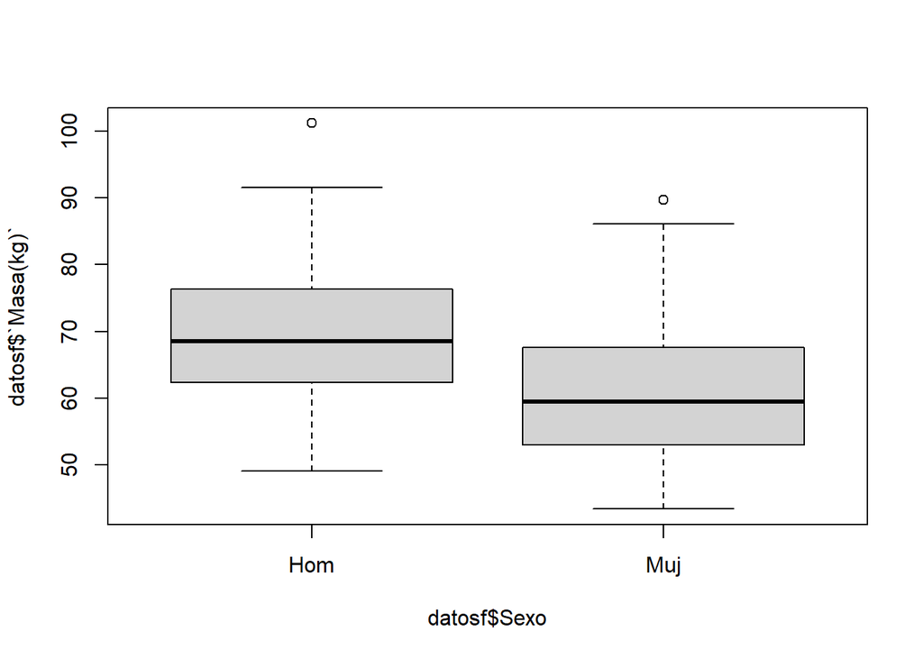

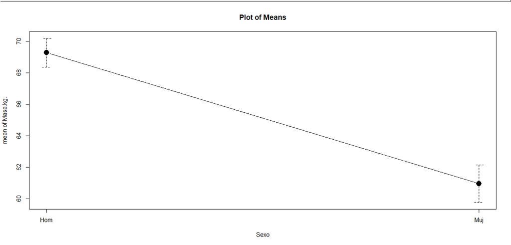

## Longman(cm)

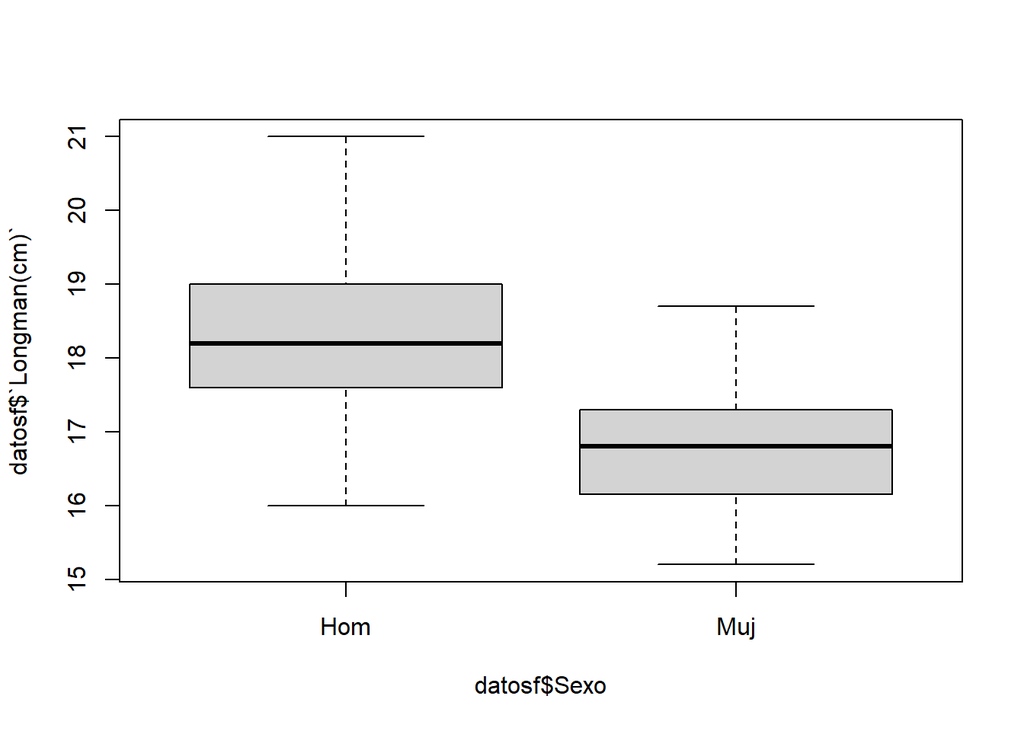

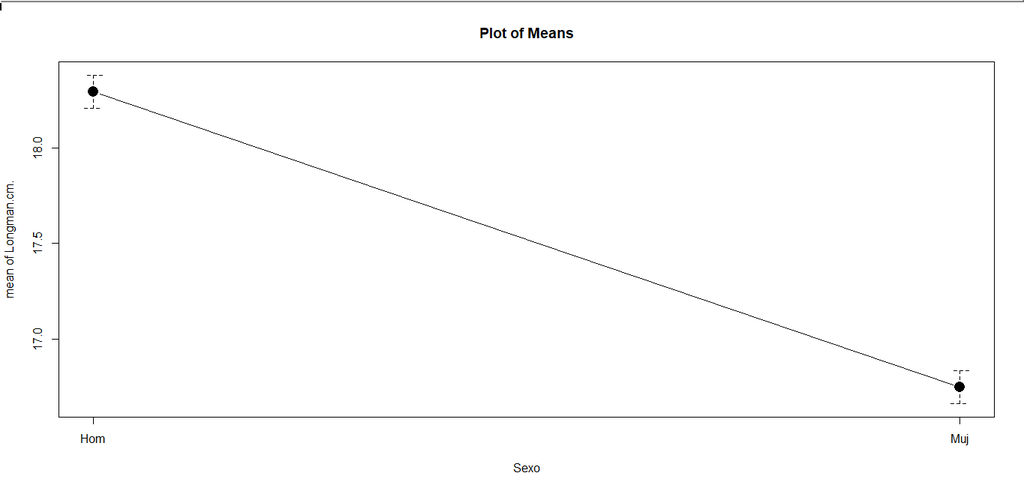

# Estatura(cm)

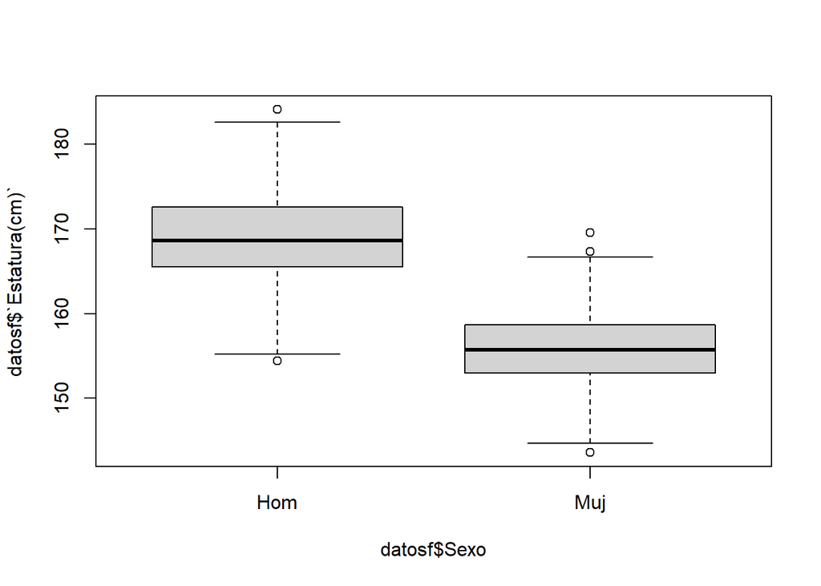

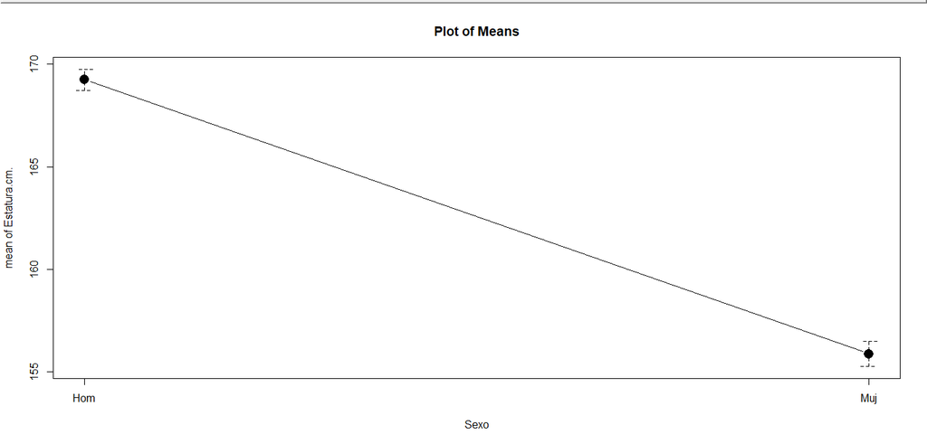

```r
#ggpairs(datosf)
```